# Data formats

Author

Nicolas Bartzsch

# Part 1: Data preparation

## Task 1: Load packages

The required packages for this homework exercise have already been added.

1. Run the code chunk below to load the required packages. Tipp: Click on the green play button in the top right corner of the code chunk.
2. What’s the `tidyverse` Package? Describe in maximum two sentences below.

```r
library(tidyverse)
library(ggthemes)
library(viridis)

#the tidyverse is a package containing various other packages such as dplyr ggplot2 and others that make data manipulation easier. Also with packages like ggplot data visualization is very accessible.
```

## Task 2: Import data

1. Use the `read_csv()` (**Note**: Watch out for the `_` and don’t use the `.` as in `read.csv()`) function to import the “msw-generation-and-composition-by-income.csv” data from the `data` directory and assign it to an object with the name `waste_data`.

```r
waste_data <- read_csv('data/msw-generation-and-composition-by-income.csv')
```

## Task 3: Vector coercion

```r
waste_data |>
  count(income_cat)
```

```
# A tibble: 4 × 2
  income_cat              n
  <chr>               <int>
1 high income            81
2 low income             33
3 lower-middle income    47
4 upper-middle income    56
```

```r
levels_income_cat <-
  c("high income",
    "upper-middle income",
    "lower-middle income",
    "low income")

waste_data_fct <- waste_data |>
  mutate(income_cat = factor(income_cat, levels = levels_income_cat))
```

## Task 4: From wide to long

1. Starting with the `waste_data_fct` object, use the `pivot_longer()` function to convert the data frame from a wide to a long format. Apply the following:
- bring all columns from `food_organic_waste` to `yard_garden_green_waste` into a long format
- send the variable names to a column named “waste_category”
- send the values of the variables to a column named “percent”
2. Remove all `NA`s from the `percent` variable
3. Assign the created data frame to an object with the name `waste_data_long`
4. Render and fix any errors

```r
waste_data_long <- waste_data_fct |>
  pivot_longer(cols = food_organic_waste:yard_garden_green_waste,
               names_to = "waste_category",
               values_to = "percent") |>
  drop_na(percent)
```

# Part 2: Data summary

## Task 1: Import data

I have stored the data that I would have expected at the end of the previous task and import it here.

1. Run the code in the code chunk below.

```r
waste_data_long <- read_rds("data/msw-generation-and-composition-by-income-long.rds")
```

## Task 2: Summarise data

1. Starting with `waste_data_long`, group the data by`income_cat` and `waste_category`, then create a summary table containing the mean of percentages (call this mean_percent) for each group.
2. Assign the created data frame to an object with the name `waste_data_long_mean`.

```r
waste_data_long_mean <- waste_data_long |>
  group_by(income_cat, waste_category) |>
  summarise(mean_percent = mean(percent))
```

## Task 3: Table display

1. Starting with the `waste_data_long_mean` object, execute the code and observe the output in the Console. Would you publish this table in this format in a report?

```r
waste_data_long_mean
```

```
# A tibble: 36 × 3
# Groups:   income_cat [4]
   income_cat          waste_category          mean_percent
   <fct>               <chr>                          <dbl>
 1 high income         food_organic_waste             32.8
 2 high income         glass                           6.12
 3 high income         metal                           5.13
 4 high income         other                          16.8
 5 high income         paper_cardboard                21.3
 6 high income         plastic                        12.4
 7 high income         rubber_leather                  2.98
 8 high income         wood                            5.54
 9 high income         yard_garden_green_waste         9.31
10 upper-middle income food_organic_waste             45.4
# ℹ 26 more rows
```

## Task 4: From long to wide

1. Starting with the `waste_data_long_mean` object, use the pipe operator to add another line of code which uses the `pivot_wider()` function to bring the data from a long format into a wide format using names for variables from `waste_category` and corresponding values from `mean_percent`
2. Execute the code and observe the output in the Console. Would you publish this table in a report in this format?
3. Render and fix any errors

```r
waste_data_long_mean |>
  pivot_wider(names_from = "waste_category",
              values_from = "mean_percent")
```

```
# A tibble: 4 × 10
# Groups:   income_cat [4]
  income_cat        food_organic_waste glass metal other paper_cardboard plastic
  <fct>                          <dbl> <dbl> <dbl> <dbl>           <dbl>   <dbl>
1 high income                     32.8  6.12  5.13  16.8           21.3    12.4
2 upper-middle inc…               45.4  4.42  3.88  18.2           12.1    12.3
3 lower-middle inc…               50.4  3.68  3.92  16.5           10.6    11.1
4 low income                      50.9  1.94  2.58  28.5            8.35    7.97
# ℹ 3 more variables: rubber_leather <dbl>, wood <dbl>,
#   yard_garden_green_waste <dbl>
```

# Part 3: Data visualization

## Task 1: Import data

I have stored the data that I would have expected at the end of the previous task and import it here.

1. Run the code in the code chunk below.

```r
waste_data_long_mean <- read_rds("data/msw-generation-and-composition-by-income-long-mean.rds")
```

## Task 2: Reproduce a plot

1. Render and fix any errors.
2. Reproduce the plot that you see as an image below when you render the report and view the output in your Viewer tab in the bottom right window.

**Hint:** To get those bars displayed next to each other, use the `geom_col()` function and apply the `position = position_dodge()` argument and value. The colors don’t have to be exactly the same colors, just not the default color scale.

**Note:** The size of the plot will be different. That is alright and does not need to match.

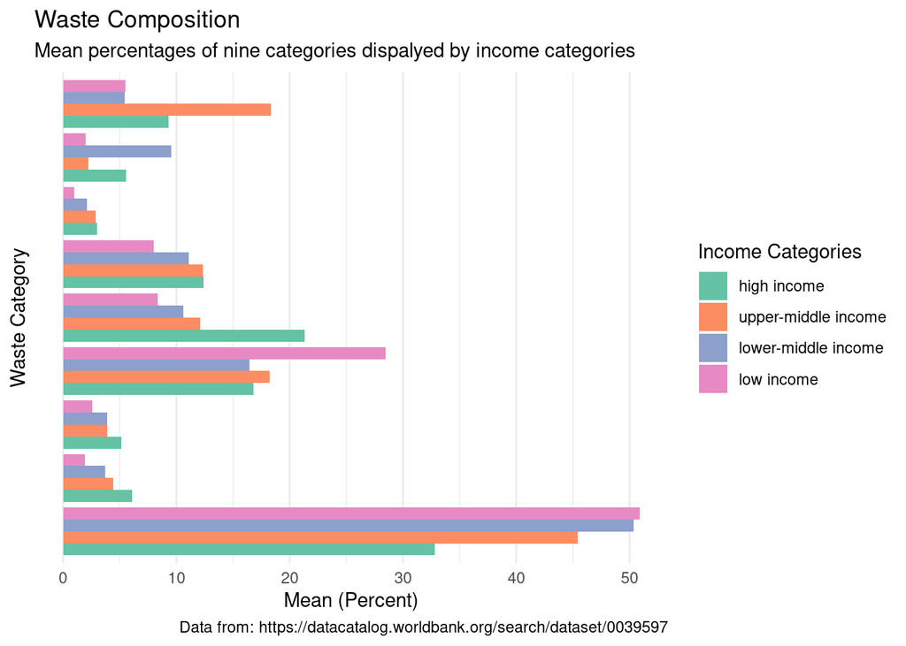

```r
ggplot(data = waste_data_long_mean,
       mapping = aes(x = mean_percent,
                     y = waste_category,
                     fill = income_cat)) +
  geom_col(position = position_dodge()) +
  scale_color_colorblind() +
  theme_minimal() +
  scale_y_discrete(breaks = NULL) +
  labs(title = "Waste Composition",
       subtitle = "Mean percentages of nine categories dispalyed by income categories",
       y = "Waste Category",
       x = "Mean (Percent)",
       fill = "Income Categories",
       caption = "Data from: https://datacatalog.worldbank.org/search/dataset/0039597") +
  scale_fill_brewer(palette = "Set2")
```

```r
#i am not sure how to add the names of the waste categories to the plot.
```

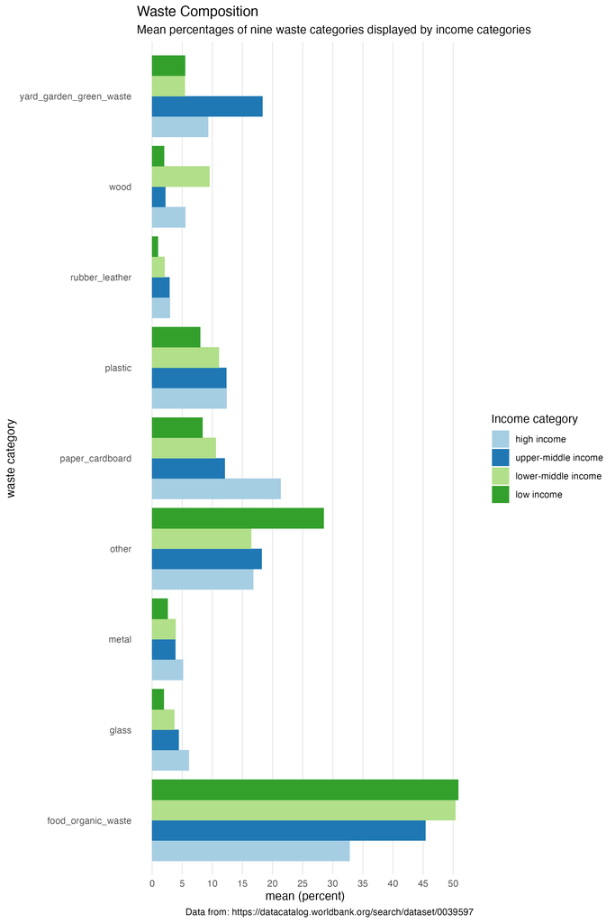

# Part 4: Complete the assignment

## Task 1: Data communication

**In the YAML header (between the three dashes at the top of the document)**

1. Add your name as the author of this document
2. Render the document and fix any errors

## Task 2: Stage, Commit & Push to GitHub

1. Open the Git pane in RStudio. It’s in the top right corner in a separate tab.
2. **Stage** your changes by checking appropriate box next to all files (if you select one file with your mouse, you can then highlight them all with Ctrl + A on your keyboard and check all boxes)
3. Write a meaningful commit message (e.g. “Completed homework assignment 06”) in the **Commit message** box
4. Click **Commit**. Note that every commit needs to have a commit message associated with it.

### Open an issue on GitHub

1. Open [github.com](https://github.com/) in your browser.
2. Navigate to the GitHub organisation for the course.
3. Find the repository md-06-assignments that ends with your GitHub username.
4. Click on the “Issues” tab.
5. Click on the green “New issue” button.
6. In the “Title” field write: “Completed module 6 assignments”.
7. In the “Leave a comment” field, tag the course instructors @larnsce and ask some questions, if you like.